# Plotly

Hannah Bougdah & Alex Ma

29 July 2019

## coffee and coding: Plotly

Today’s presentation

- What is Plotly?
- Online resources
- example code using ggplot as a basis
- example code using plotly

## Plotly

- Plotly is a graphing library which makes interactive html graphs.
- It uses the open source JavaScript graphing library **plotly.js**.
- Great for building dashboards or allowing the user to interact with the data themselves.

## Getting started

- Graphing library with example code: https://plot.ly/r/
- Cheat sheet (paste into web browser): https://images.plot.ly/plotly-documentation/images/r_cheat_sheet.pdf
- Book is available too: https://plotly-r.com/index.html

## Functionality

[interactive chart not shown]

## Why use Plotly?

- Good for exploring the data.
- Allow other users to explore the data.
- Easily save and download the charts you create in plotly.
- Not neccessarily good for publication - the charts are html.
- Useful in exploratory analysis or QA notes.

## Using plotly

There are two ways to use plotly:

- the easier way (less options)
- the harder way (more options)

## The easier way

The easier way involves creating charts using **ggplot2** and then using the **ggplotly** function from plotly to make the ggplot chart interactive.

This is a quick, easy way to create interactive charts, however loses some of the functionality of the plotly package.

## The easier way - example 1

```r
# ggplot + plotly chart - month
p_date <- ggplot(crashes_dates, aes(month, n))+
  geom_line(aes(colour = Casualty_Type), size = 1) +
  ylab("Casualties per month") +
  theme(axis.title = element_text(family = "Arial", size = 7)) +
  scale_x_continuous(breaks = round(seq(min(crashes_dates$month), max(crashes_dates$month), by = 1.0),1)) +
  scale_y_continuous(breaks = seq(0, 9000, by = 1000)) +
  scale_color_manual(values=dft_col(n=8, name="dft")) +
theme_classic()

ggplotly(p_date)
```

[interactive chart not shown]

## The easier way - example 2

```r
# get counts of accidents in each police force

# get count for number of accidents in each police force and weekday
pf_accidents <- accidents %>%
  dplyr::group_by(Police_Force, Day_of_Week) %>%
  dplyr::tally() %>%
  dplyr::arrange(Police_Force, Day_of_Week)


# ggplot - scatter for no. accidents in police force by week day

pf_scatter <- ggplot(pf_accidents, aes(Police_Force, n))+
  geom_point(aes(colour = Day_of_Week)) +
  ggtitle("Reported road accidents by Police Force and day of the week, 2017") +
  ylab("Number of Accidents in 2017") +
  scale_y_continuous(breaks = seq(0, 4400, by = 200)) +
  theme(axis.title = element_text(family = "Arial", size = 7)) +
   theme_classic() +
    theme(axis.text.x = element_text(angle = 90)) +
    scale_color_manual(values=dft_col(n=7, name="dft"))

ggplotly(pf_scatter)
```

[interactive chart not shown]

## create DfT colour palette

```r
# create dft colour palette

library(fBasics)

r <- c(0, 102, 210, 228, 201, 233, 0, 153)
g <- c(104, 164, 95, 159, 146, 211, 153, 214)
b <- c(83, 152, 21, 115, 18, 160, 169, 221)

dft_col <- function (n, name = c("dft"))
{
  dft = rgb(r, g, b, maxColorValue = 255)
  name = match.arg(name)
  orig = eval(parse(text = name))
  rgb = t(col2rgb(orig))
  temp = matrix(NA, ncol = 3, nrow = n)
  x = seq(0, 1, , length(orig))
  xg = seq(0, 1, , n)
  for (k in 1:3) {
    hold = spline(x, rgb[, k], n = n)$y
    hold[hold < 0] = 0
    hold[hold > 255] = 255
    temp[, k] = round(hold)
  }
  palette = rgb(temp[, 1], temp[, 2], temp[, 3], maxColorValue = 255)
  palette
}
```

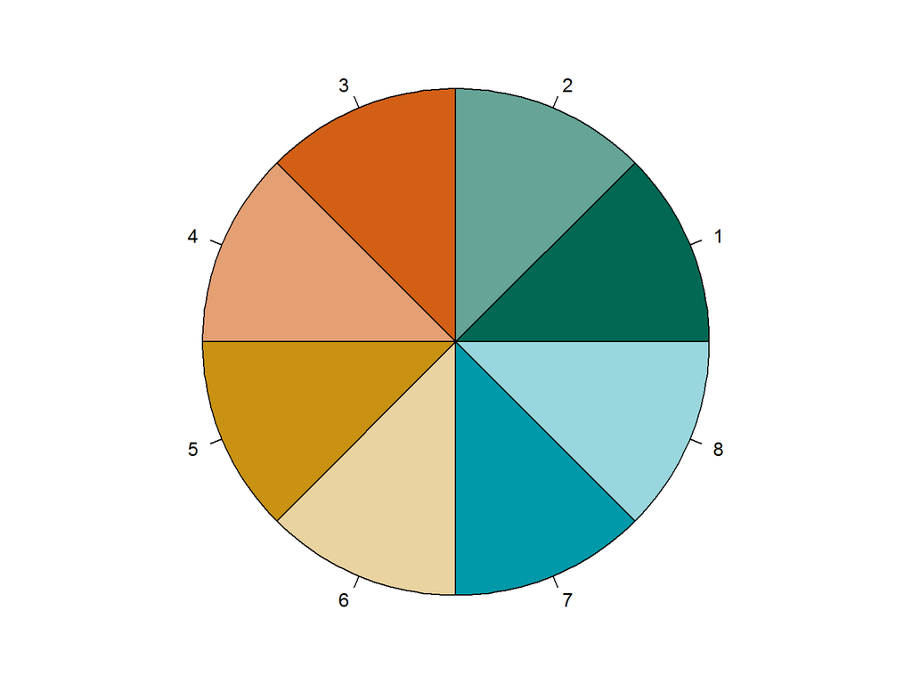

## The harder way

- Using the plot_ly() wrapper and learning a new set of arguments.
- Plotly is very flexible - double check which arguments are in which wrappers as plotly pipes arguments into each other.
- Plotly exists in R, Python, MATLAB and JaveScript. When searching for guidance on arguments, make sure it’s the correct language.
- Plot_ly() over ggplotly() provides you with more options to control, including animating graphs with timelines, buttons and sliders.

## Bar Charts in plotly

```r
#Grouping accidents by police force
accidentsPF <- accidents %>%          #SQL FROM clause equivalent
  dplyr::group_by(Police_Force) %>%   #SQL SELECT/GROUP BY clause equivalent
  dplyr::tally()                      #SQL count(*) equivalent



#reorder the data so that you change the police forces to graph in descending order
accidentsPF$Police_Force <- factor(accidentsPF$Police_Force,
                                   levels = unique(accidentsPF$Police_Force)[order(accidentsPF$n, decreasing = TRUE)])


#adding more information for the bar chart
accidentsPF$percent <- (accidentsPF$n/129982)*100
accidentsPF$percent <- round(accidentsPF$percent, 1)


#creating a bar chart
accidentsPF %>%
  plot_ly(
    y = ~ Police_Force, #use a ~ to tell plot_ly that you want to reference a variable
    x = ~ n,
    type = "bar", #specifies what chart you want
    marker = list(color = 'rgb(210,95,21)'),
    hoverinfo = "text", #dialogue box that appears when you mouse over a data point
    hovertext = paste(
      "<b>Force: </b>", accidentsPF$Police_Force,
      "<i><br>Count: </i>",accidentsPF$n,
      "<br>Per cent: ", accidentsPF$percent)
    ) %>%
      layout(title = "Personal injury reported road accidents in 2017 by Police Force",
             xaxis = list(title = "Count",
                          showgrid = F,
                          zeroline = F),
             yaxis = list(title = "Police Force",
                          showgrid = F,
                          zeroline = F)
              )
```

[interactive chart not shown]

## Scatter charts in plotly

```r
con <- dbConnect(odbc::odbc(),
                 .connection_string = "Driver={SQL Server};Server=TS01;Database=RAS_analysis;Trusted_Connection=True;believeNRows=FALSE, rows_at_time=1, as.is")

accidentsscatter <- dbGetQuery(con,
                              "select a.accyr as year, a1lab as policeforce,  count(distinct a.accid) as accidents, count(*) as casualties
                              from cas c left join acc a on c.accid=a.accid
                              where a.accyr between 2000 and 2018
                              group by a.accyr, a1lab
                              order by a.accyr")
```

```r
accidentsscatter %>%
  plot_ly() %>%
  add_trace(
    x = ~ accidents,
    y = ~ casualties,
    color = ~ policeforce,
    frame = ~ year,
    type = 'scatter',
    mode = 'markers',
    hoverinfo = "text",
    text = ~paste('</br><b>Force</b>: ',policeforce,'</br>Accidents: ',accidents,'</br>casualties: ',casualties)
  ) %>% animation_opts(
    1000, #animation speed in ms
    easing = "elastic", #adds "elastic animation effect
    redraw = FALSE #TRUE will redraw plot at the completion of the transition
  ) %>%
  layout(title = "Accidents and casualties by Police Force 2000-2018",
         xaxis = list(title = "Accidents"),
         yaxis = list(title = "Casualties")
  )
```

[interactive chart not shown]

## Heatmap/Matrix

```r
#create dft colour scale for heatmap
palette <- colorRampPalette(c("#F4E9D0","#C99212"))


  plot_ly(
    data = accidentsheatmap,
    x = ~ hour2,
    y = ~ DayofWeek,
    z = ~ n,
    type = "heatmap",
    colors =  palette(3700)
    ) %>%
  layout(title = "Personal injury reported road accidents in 2017 by time and day of week",
         xaxis = list(title = "Time"),
         yaxis = list(title = "Day of week"),
         hoverlabel = list(font=list(size=20))
  )
```

[interactive chart not shown]